# EasyVisa Project

### XGBoost Classifier

```python
# Choose the type of classifier.
xgb_tuned = XGBClassifier(random_state=1,eval_metric='logloss')

# Grid of parameters to choose from
## add from
parameters = {
    "n_estimators": np.arange(10,40,20),
    "scale_pos_weight":[0,1],
    "subsample":[0.9,1],
    "learning_rate":[0.2,0.05],
    "gamma":[0,1],
    "colsample_bytree":[0.5,0.7],
    "colsample_bylevel":[0.9,1]
}

# Type of scoring used to compare parameter combinations
acc_scorer = metrics.make_scorer(metrics.recall_score)

# Run the grid search
grid_obj = GridSearchCV(xgb_tuned, parameters,scoring=acc_scorer,cv=5)
grid_obj = grid_obj.fit(X_train, y_train)

# Set the clf to the best combination of parameters
xgb_tuned = grid_obj.best_estimator_

# Fit the best algorithm to the data.
xgb_tuned.fit(X_train, y_train)
```

```
XGBClassifier(base_score=None, booster=None, callbacks=None,
              colsample_bylevel=0.9, colsample_bynode=None,
              colsample_bytree=0.7, early_stopping_rounds=None,
              enable_categorical=False, eval_metric='logloss',
              feature_types=None, gamma=1, gpu_id=None, grow_policy=None,
              importance_type=None, interaction_constraints=None,
              learning_rate=0.2, max_bin=None, max_cat_threshold=None,
              max_cat_to_onehot=None, max_delta_step=None, max_depth=None,
              max_leaves=None, min_child_weight=None, missing=nan,
              monotone_constraints=None, n_estimators=30, n_jobs=None,
              num_parallel_tree=None, predictor=None, random_state=1, ...)
```

```python
#Using above defined function to get accuracy, recall and precision on train and test set
xgb_tuned_score=get_metrics_score(xgb_tuned)
```

```
Accuracy on training set :  0.7730993496299619
Accuracy on test set :  0.7527472527472527
Recall on training set :  0.5311497551916259
Recall on test set :  0.4986215045293423
Precision on training set :  0.7124094202898551
Precision on test set :  0.6723313860860329
```

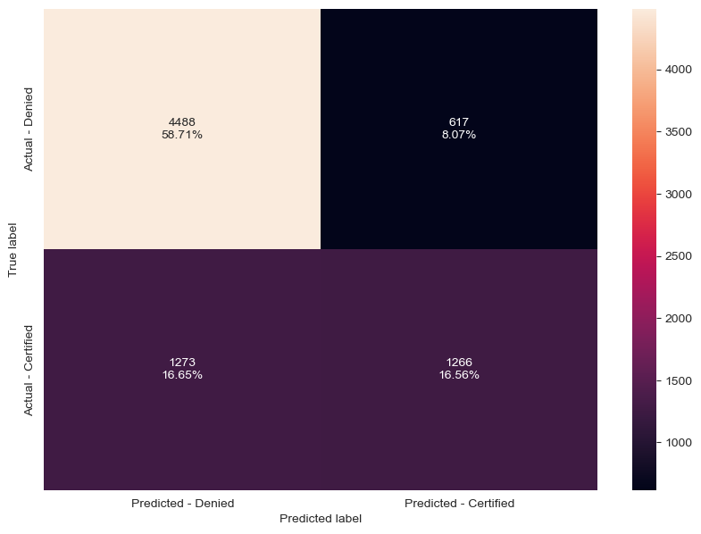

```python
make_confusion_matrix(xgb_tuned,y_test)
```

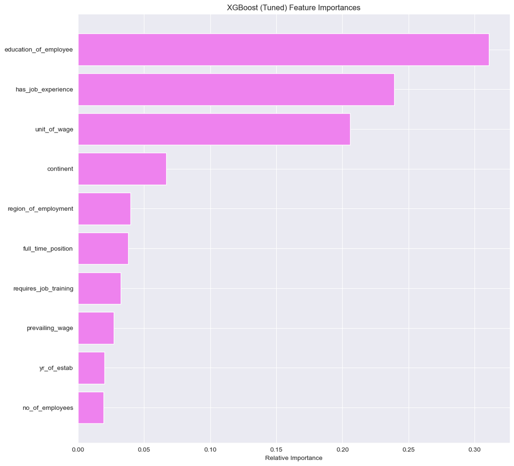

```python
importances = xgb_tuned.feature_importances_
indices = np.argsort(importances)
feature_names = list(X.columns)

plt.figure(figsize=(12,12))
plt.title('XGBoost (Tuned) Feature Importances')
plt.barh(range(len(indices)), importances[indices], color='violet', align='center')
plt.yticks(range(len(indices)), [feature_names[i] for i in indices])
plt.xlabel('Relative Importance')
plt.show()
```

**Observations:**

- Like the previous models, this model has pretty good accuracy and precision scores, with a lower recall score.
- education_of_employee is the most important factor

### Stacking Model

```python
estimators=[('Decision Tree', dtree_tuned), ('Bagging_Tuned', bagging_estimator_tuned),
            ('Random Forest', rf_estimator_weighted),
           ('Gradient Boosting', gbc_tuned), ('AdaBoost', abc_tuned)
           ]
final_estimator=XGBClassifier(random_state=1)
```

```python
stacking_estimator=StackingClassifier(estimators=estimators, final_estimator=final_estimator,cv=5)
stacking_estimator.fit(X_train,y_train)
```

```
StackingClassifier(cv=5,
                   estimators=[('Decision Tree',
                                DecisionTreeClassifier(max_depth=3,
                                                       max_leaf_nodes=10,
                                                       min_impurity_decrease=0.01,
                                                       random_state=1)),
                               ('Bagging_Tuned',
                                BaggingClassifier(max_features=7, max_samples=1,
                                                  random_state=1)),
                               ('Random Forest',
                                RandomForestClassifier(class_weight={0: 0.33,
                                                                     1: 0.67},
                                                       max_features=0.2,
                                                       max_samples=0.3,
                                                       min_samples_leaf=9,...
                                                 gpu_id=None, grow_policy=None,
                                                 importance_type=None,
                                                 interaction_constraints=None,
                                                 learning_rate=None,
                                                 max_bin=None,
                                                 max_cat_threshold=None,
                                                 max_cat_to_onehot=None,
                                                 max_delta_step=None,
                                                 max_depth=None,
                                                 max_leaves=None,
                                                 min_child_weight=None,
                                                 missing=nan,
                                                 monotone_constraints=None,
                                                 n_estimators=100, n_jobs=None,
                                                 num_parallel_tree=None,
                                                 predictor=None, random_state=1, ...))
```

```python
#Using above defined function to get accuracy, recall and precision on train and test set
stacking_score=get_metrics_score(stacking_estimator)
```

```
Accuracy on training set :  0.7507849293563579
Accuracy on test set :  0.7429356357927787
Recall on training set :  0.508188418031403
Recall on test set :  0.4915320992516739
Precision on training set :  0.662703654777631
Precision on test set :  0.6493236212278877
```

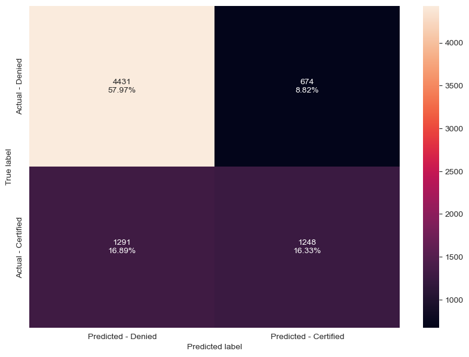

```python
make_confusion_matrix(stacking_estimator,y_test)
```

**Observations:**

- Accuracy and Precision scores are not bad, but the Recall score is less than optimal

## Comparing All Models

```python
# defining list of models
models = [abc, abc_tuned, gbc, gbc_init, gbc_tuned, xgb, xgb_tuned, stacking_estimator]

# defining empty lists to add train and test results
acc_train = []
acc_test = []
recall_train = []
recall_test = []
precision_train = []
precision_test = []

# looping through all the models to get the accuracy, precall and precision scores
for model in models:
    j = get_metrics_score(model,False)
    acc_train.append(np.round(j[0],2))
    acc_test.append(np.round(j[1],2))
    recall_train.append(np.round(j[2],2))
    recall_test.append(np.round(j[3],2))
    precision_train.append(np.round(j[4],2))
    precision_test.append(np.round(j[5],2))
```

```python
comparison_frame = pd.DataFrame({'Model':['AdaBoost with default paramters','AdaBoost Tuned',
                                          'Gradient Boosting with default parameters','Gradient Boosting with init=AdaBoost',
                                          'Gradient Boosting Tuned','XGBoost with default parameters','XGBoost Tuned', 'Stacking Model'],
                                          'Train_Accuracy': acc_train,'Test_Accuracy': acc_test,
                                          'Train_Recall':recall_train,'Test_Recall':recall_test,
                                          'Train_Precision':precision_train,'Test_Precision':precision_test})
BoostingFrame = comparison_frame
BoostingFrame
```

|  | Model | Train_Accuracy | Test_Accuracy | Train_Recall | Test_Recall | Train_Precision | Test_Precision |
| --- | --- | --- | --- | --- | --- | --- | --- |
| 0 | AdaBoost with default paramters | 0.74 | 0.73 | 0.43 | 0.42 | 0.66 | 0.66 |
| 1 | AdaBoost Tuned | 0.75 | 0.75 | 0.51 | 0.50 | 0.66 | 0.66 |
| 2 | Gradient Boosting with default parameters | 0.75 | 0.75 | 0.50 | 0.50 | 0.67 | 0.67 |
| 3 | Gradient Boosting with init=AdaBoost | 0.76 | 0.75 | 0.51 | 0.50 | 0.68 | 0.67 |
| 4 | Gradient Boosting Tuned | 0.76 | 0.75 | 0.50 | 0.49 | 0.68 | 0.67 |
| 5 | XGBoost with default parameters | 0.84 | 0.74 | 0.64 | 0.48 | 0.83 | 0.64 |
| 6 | XGBoost Tuned | 0.77 | 0.75 | 0.53 | 0.50 | 0.71 | 0.67 |
| 7 | Stacking Model | 0.75 | 0.74 | 0.51 | 0.49 | 0.66 | 0.65 |

**Observations:**

- Many of the models were very similar, but the XGBoost Tuned model performed the best
- While maintaining similar values between the train and test sets, the XGBoost Tuned Model performed well in precision and accuracy. The recall score, while low, was higher than most of the other models' scores and was still relatively close between the train and test sets

## Will tuning the hyperparameters improve the model performance?

- For the Decision Tree, the scores of the tuned model were much closer between the train and test sets. There was less overfitting compared the the default model
- For Bagging, tuning the model decreased the performance. The default model overfit the train set, but the tuned model had severely low accuracy and precision and a recall score of 1.0 for both the train and test sets
- For Random Forest, the tuned model performed better than the default model, and about the same as the weighted model. The tuned model fixed the overfitting that occured in the default model, and had a higher precision score, but lower recall score than the weighted model
- For ADABoost, the tuned model peformed slightly better on the recall score than with the default parameters, while the other scores remained fairly similar
- For Gradient Boost, the scores did not change much between boosting with default parameters, with init= ADABoost, and Tuned
- For XGBoost, the accuracy scores were improved in between the train and test sets in the Tuned model vs the default parameters. The score of the Train accuracy fell, but it overfitted the train data set, which was fixed in the Tuned model. The same thing happened with both the Recall and Precision scores. The default training set overfit and the Tuned resolved the scores

## Model Performance Comparison and Conclusions

### Comparisons:

```python
Important_Features = pd.DataFrame({'Model': ['Decision Tree with default parameters',
                                            'Tuned Decision Tree',
                                             'Random Forest with default parameters',
                                            'Tuned Random Forest Classifier',
                                            'Random Forest with class_weights',
                                            'AdaBoost with default parameters',
                                            'AdaBoost Tuned',
                                            'Gradient Boosting with default parameters',
                                            'Gradient Boosting with ini=AdaBoost',
                                            'Gradient Boost Tuned',
                                            'XGBoost with default parameters',
                                            'XGBoost Tuned'],
                                     '1st': ['prevailing_wage', 'education_of_employee',
                                            'prevailing_wage','education_of_employee',
                                            'education_of_employee','education_of_employee',
                                            'education_of_employee','education_of_employee',
                                            'education_of_employee','education_of_employee',
                                            'unit_of_wage','education_of_employee'],
                                     '2nd': ['no_of_employees', 'unit_of_wage',
                                            'no_of_employees', 'prevailing_wage',
                                            'prevailing_wage', 'region_of_employement',
                                            'no_of_employees', 'has_job_experience',
                                            'has_job_experience', 'has_job_experience',
                                            'education_of_employee','has_job_experience'],
                                     '3rd': ['yr_of_estab', 'NaN',
                                            'yr_of_estab', 'no_of_employees',
                                            'has_job_experience', 'prevailing_wage',
                                            'continent', 'unit_of_wage',
                                            'unit_of_wage', 'unit_of_wage',
                                            'has_job_experience', 'unit_of_wage']})
Important_Features
```

|  | Model | 1st | 2nd | 3rd |
| --- | --- | --- | --- | --- |
| 0 | Decision Tree with default parameters | prevailing_wage | no_of_employees | yr_of_estab |
| 1 | Tuned Decision Tree | education_of_employee | unit_of_wage | NaN |
| 2 | Random Forest with default parameters | prevailing_wage | no_of_employees | yr_of_estab |
| 3 | Tuned Random Forest Classifier | education_of_employee | prevailing_wage | no_of_employees |
| 4 | Random Forest with class_weights | education_of_employee | prevailing_wage | has_job_experience |
| 5 | AdaBoost with default parameters | education_of_employee | region_of_employement | prevailing_wage |
| 6 | AdaBoost Tuned | education_of_employee | no_of_employees | continent |
| 7 | Gradient Boosting with default parameters | education_of_employee | has_job_experience | unit_of_wage |
| 8 | Gradient Boosting with ini=AdaBoost | education_of_employee | has_job_experience | unit_of_wage |
| 9 | Gradient Boost Tuned | education_of_employee | has_job_experience | unit_of_wage |
| 10 | XGBoost with default parameters | unit_of_wage | education_of_employee | has_job_experience |
| 11 | XGBoost Tuned | education_of_employee | has_job_experience | unit_of_wage |

```python
Important_Features['1st'].value_counts()
```

```
education_of_employee    9
prevailing_wage          2
unit_of_wage             1
Name: 1st, dtype: int64
```

```python
Important_Features['2nd'].value_counts()
```

```
has_job_experience       4
no_of_employees          3
prevailing_wage          2
unit_of_wage             1
region_of_employement    1
education_of_employee    1
Name: 2nd, dtype: int64
```

```python
Important_Features['3rd'].value_counts()
```

```
unit_of_wage          4
yr_of_estab           2
has_job_experience    2
NaN                   1
no_of_employees       1
prevailing_wage       1
continent             1
Name: 3rd, dtype: int64
```

```python
# defining list of models
models = [dtree, dtree_tuned, bagging_estimator,bagging_estimator_tuned,bagging_lr,rf_estimator,rf_estimator_tuned,
          rf_estimator_weighted,
          abc, abc_tuned, gbc, gbc_init, gbc_tuned, xgb, xgb_tuned, stacking_estimator
          ]

# defining empty lists to add train and test results
acc_train = []
acc_test = []
recall_train = []
recall_test = []
precision_train = []
precision_test = []

# looping through all the models to get the accuracy, precall and precision scores
for model in models:
    j = get_metrics_score(model,False)
    acc_train.append(np.round(j[0],2))
    acc_test.append(np.round(j[1],2))
    recall_train.append(np.round(j[2],2))
    recall_test.append(np.round(j[3],2))
    precision_train.append(np.round(j[4],2))
    precision_test.append(np.round(j[5],2))
```

```python
comparison_frame = pd.DataFrame({'Model':['Decision Tree with default parameters', 'Tuned Decision Tree','Bagging classifier with default parameters','Tuned Bagging Classifier',
                                        'Bagging classifier with base_estimator=LR', 'Random Forest with default parameters',
                                         'Tuned Random Forest Classifier','Random Forest with class_weights',
                                          'AdaBoost with default parameters','AdaBoost Tuned',
                                          'Gradient Boosting with default parameters','Gradient Boosting with init=AdaBoost',
                                          'Gradient Boosting Tuned','XGBoost with default parameters','XGBoost Tuned', 'Stacking Model'],
                                          'Train_Accuracy': acc_train,'Test_Accuracy': acc_test,
                                          'Train_Recall':recall_train,'Test_Recall':recall_test,
                                          'Train_Precision':precision_train,'Test_Precision':precision_test})
AllModels = comparison_frame
AllModels
```

|  | Model | Train_Accuracy | Test_Accuracy | Train_Recall | Test_Recall | Train_Precision | Test_Precision |
| --- | --- | --- | --- | --- | --- | --- | --- |
| 0 | Decision Tree with default parameters | 1.00 | 0.66 | 1.00 | 0.50 | 1.00 | 0.49 |
| 1 | Tuned Decision Tree | 0.73 | 0.74 | 0.40 | 0.40 | 0.64 | 0.67 |
| 2 | Bagging classifier with default parameters | 0.98 | 0.72 | 0.95 | 0.45 | 0.99 | 0.60 |
| 3 | Tuned Bagging Classifier | 0.33 | 0.33 | 1.00 | 1.00 | 0.33 | 0.33 |
| 4 | Bagging classifier with base_estimator=LR | 0.67 | 0.67 | 0.00 | 0.00 | 0.00 | 0.00 |
| 5 | Random Forest with default parameters | 1.00 | 0.74 | 1.00 | 0.49 | 1.00 | 0.63 |
| 6 | Tuned Random Forest Classifier | 0.78 | 0.75 | 0.51 | 0.46 | 0.75 | 0.67 |
| 7 | Random Forest with class_weights | 0.75 | 0.73 | 0.68 | 0.65 | 0.61 | 0.59 |
| 8 | AdaBoost with default parameters | 0.74 | 0.73 | 0.43 | 0.42 | 0.66 | 0.66 |
| 9 | AdaBoost Tuned | 0.75 | 0.75 | 0.51 | 0.50 | 0.66 | 0.66 |
| 10 | Gradient Boosting with default parameters | 0.75 | 0.75 | 0.50 | 0.50 | 0.67 | 0.67 |
| 11 | Gradient Boosting with init=AdaBoost | 0.76 | 0.75 | 0.51 | 0.50 | 0.68 | 0.67 |
| 12 | Gradient Boosting Tuned | 0.76 | 0.75 | 0.50 | 0.49 | 0.68 | 0.67 |
| 13 | XGBoost with default parameters | 0.84 | 0.74 | 0.64 | 0.48 | 0.83 | 0.64 |
| 14 | XGBoost Tuned | 0.77 | 0.75 | 0.53 | 0.50 | 0.71 | 0.67 |
| 15 | Stacking Model | 0.75 | 0.74 | 0.51 | 0.49 | 0.66 | 0.65 |